## Chapter 5: Dimensionality Reduction Techniques.

### 5.2.1.Data graphical overview and variables’ summary.

To visualize the data, we use both `ggpairs()` and `corrplot()`:

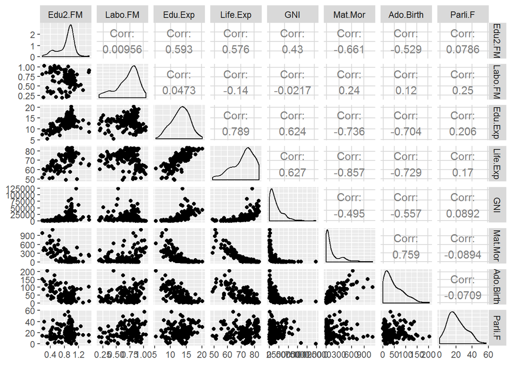

```r
library(GGally); library(corrplot); library(dplyr)
ggpairs(human_)
```

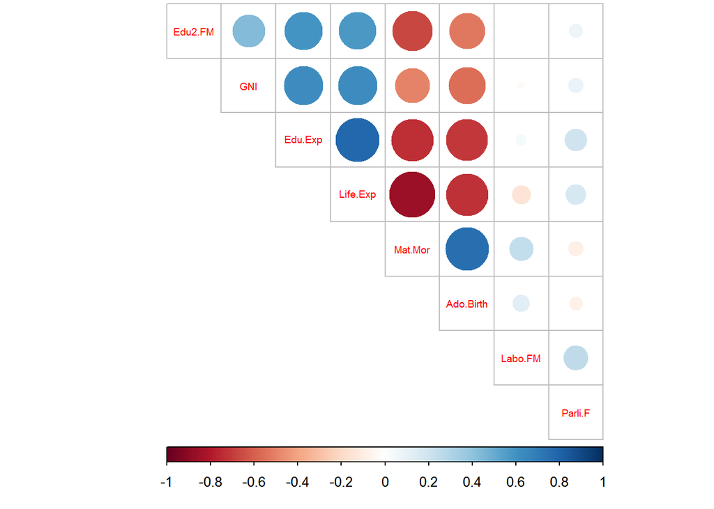

```r
cor(human_) %>% corrplot(method="circle", type = "upper", cl.pos = "b", tl.pos = "d", tl.cex = 0.6, order = "hclus")
```

### 5.2.2.Principal Component Analysis (PCA) on not standardized data.

PCA is a statistical procedure that decomposes a matrix into a product of smaller matrices and revals the most important components. In other words, the data are transformed into a new space with equal or less number of dimensions. The first dimension reveals the maximum amount of variance from the features in the original data. As for the second component, it captures the maximum amount of variability left. The principal components are uncorrelated, and the importance of captured variance decreases for each of them. In this paragraph we run a PCA on the data visible in the following `summary()`. We will use the function `prcomp()`that employs the more numerically accurate Singular Value Decomposition (SVD).

```
##     Edu2.FM          Labo.FM          Edu.Exp         Life.Exp
##  Min.   :0.1717   Min.   :0.1857   Min.   : 5.40   Min.   :49.00
##  1st Qu.:0.7264   1st Qu.:0.5984   1st Qu.:11.25   1st Qu.:66.30
##  Median :0.9375   Median :0.7535   Median :13.50   Median :74.20
##  Mean   :0.8529   Mean   :0.7074   Mean   :13.18   Mean   :71.65
##  3rd Qu.:0.9968   3rd Qu.:0.8535   3rd Qu.:15.20   3rd Qu.:77.25
##  Max.   :1.4967   Max.   :1.0380   Max.   :20.20   Max.   :83.50
##       GNI            Mat.Mor         Ado.Birth         Parli.F
##  Min.   :   581   Min.   :   1.0   Min.   :  0.60   Min.   : 0.00
##  1st Qu.:  4198   1st Qu.:  11.5   1st Qu.: 12.65   1st Qu.:12.40
##  Median : 12040   Median :  49.0   Median : 33.60   Median :19.30
##  Mean   : 17628   Mean   : 149.1   Mean   : 47.16   Mean   :20.91
##  3rd Qu.: 24512   3rd Qu.: 190.0   3rd Qu.: 71.95   3rd Qu.:27.95
##  Max.   :123124   Max.   :1100.0   Max.   :204.80   Max.   :57.50
```

Here we have the `summary()`for the principal component analysis:

```
## Importance of components:
##                              PC1      PC2   PC3   PC4   PC5   PC6    PC7
## Standard deviation     1.854e+04 185.5219 25.19 11.45 3.766 1.566 0.1912
## Proportion of Variance 9.999e-01   0.0001  0.00  0.00 0.000 0.000 0.0000
## Cumulative Proportion  9.999e-01   1.0000  1.00  1.00 1.000 1.000 1.0000
##                           PC8
## Standard deviation     0.1591
## Proportion of Variance 0.0000
## Cumulative Proportion  1.0000
```

Before proceeding to the plot, we set the rounded percentage of the variance captured by each principal component. In this case we choose to include only one digit, we create also the axis labels:

```r
pca_pr1 <- round(100*s1$importance[2,], digits = 1)
pca_pr1
```

```
## PC1 PC2 PC3 PC4 PC5 PC6 PC7 PC8
## 100   0   0   0   0   0   0   0
```

Then we visualize the results with a `biplot()` that displays the observations and the original features (as a scatterplot), and also their relationship with both each others and with the principal components (in form of arrows or labels):

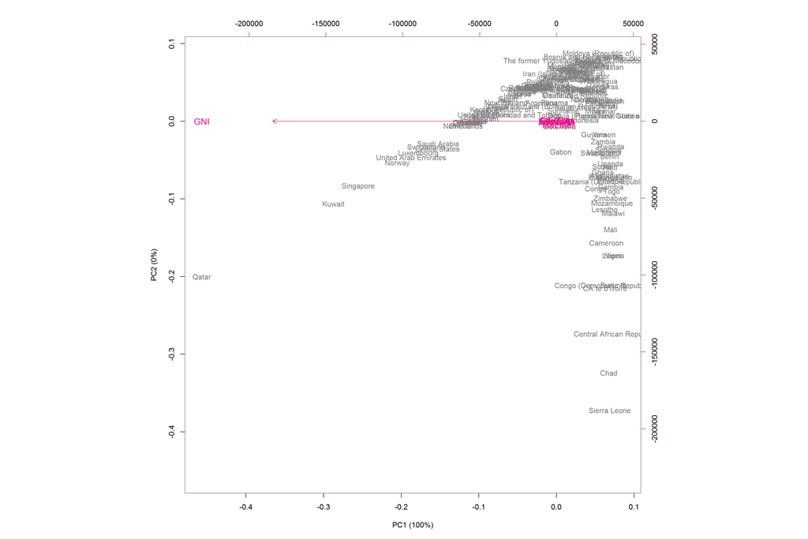

```r
biplot(pca_human1, choices = 1:2, cex = c(1, 1.2), col = c("grey50", "deeppink2"), xlab =pc_lab1[1], ylab = pc_lab1[2])
```

The variability captured by the principal components are respectively of 100% in PC1 and of 0% in PC2, also all the others PCs are 0. This result could have been influenced by the non-standardization of the data as described more below.

### 5.2.3.Principal Component Analysis (PCA) on standardized data.

It is a good idea to standardize the data because the PCA is sensitive to the relative scaling of the original features. It also assumes that features with larger variance are more important than features with smaller variance. By standardizing variables with different units, we can compare the values of these variables. So, now we repeat the same analysis with standardized variables, whose `summary()` is the following:

```
##     Edu2.FM           Labo.FM           Edu.Exp           Life.Exp
##  Min.   :-2.8189   Min.   :-2.6247   Min.   :-2.7378   Min.   :-2.7188
##  1st Qu.:-0.5233   1st Qu.:-0.5484   1st Qu.:-0.6782   1st Qu.:-0.6425
##  Median : 0.3503   Median : 0.2316   Median : 0.1140   Median : 0.3056
##  Mean   : 0.0000   Mean   : 0.0000   Mean   : 0.0000   Mean   : 0.0000
##  3rd Qu.: 0.5958   3rd Qu.: 0.7350   3rd Qu.: 0.7126   3rd Qu.: 0.6717
##  Max.   : 2.6646   Max.   : 1.6632   Max.   : 2.4730   Max.   : 1.4218
##       GNI             Mat.Mor          Ado.Birth          Parli.F
##  Min.   :-0.9193   Min.   :-0.6992   Min.   :-1.1325   Min.   :-1.8203
##  1st Qu.:-0.7243   1st Qu.:-0.6496   1st Qu.:-0.8394   1st Qu.:-0.7409
##  Median :-0.3013   Median :-0.4726   Median :-0.3298   Median :-0.1403
##  Mean   : 0.0000   Mean   : 0.0000   Mean   : 0.0000   Mean   : 0.0000
##  3rd Qu.: 0.3712   3rd Qu.: 0.1932   3rd Qu.: 0.6030   3rd Qu.: 0.6127
##  Max.   : 5.6890   Max.   : 4.4899   Max.   : 3.8344   Max.   : 3.1850
```

and here we have the`summary()`for the `PCA`:

```
## Importance of components:
##                           PC1    PC2     PC3     PC4     PC5     PC6
## Standard deviation     2.0708 1.1397 0.87505 0.77886 0.66196 0.53631
## Proportion of Variance 0.5361 0.1624 0.09571 0.07583 0.05477 0.03595
## Cumulative Proportion  0.5361 0.6984 0.79413 0.86996 0.92473 0.96069
##                            PC7     PC8
## Standard deviation     0.45900 0.32224
## Proportion of Variance 0.02634 0.01298
## Cumulative Proportion  0.98702 1.00000
```

We follow again the same procedure as for the non-standardized data, for the rounding of digits and label creation and we obtain these results:

```
##  PC1  PC2  PC3  PC4  PC5  PC6  PC7  PC8
## 53.6 16.2  9.6  7.6  5.5  3.6  2.6  1.3
```

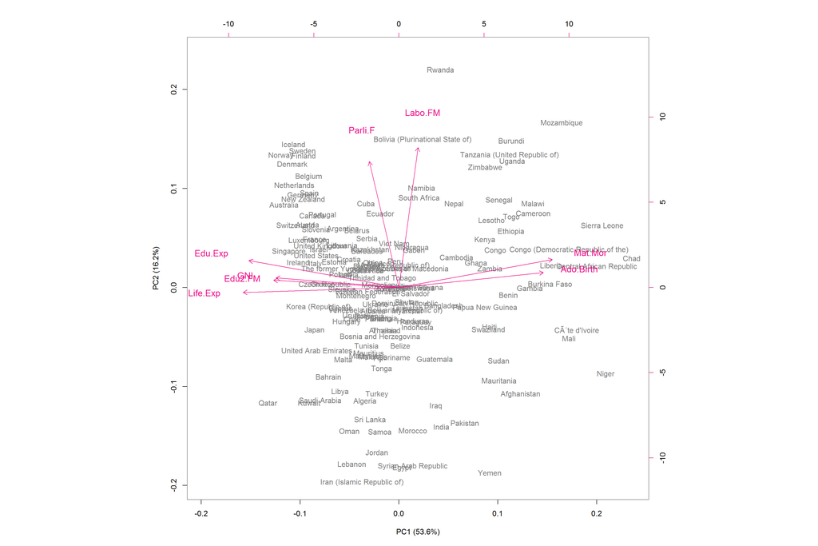

```r
biplot(pca_human2, choices = 1:2, cex = c(1, 1.2), col = c("grey50", "deeppink2"), xlab =pc_lab2[1], ylab = pc_lab2[2])
```

The results this time seem to be different. With the non-standardized data we had a PC1 that covered the 100% of the data and a PC2 with 0% as the other 6 PCs. In here, using standardized data, we have a PC1 that covers the 53,6% of the data, and then a PC2 that covers the 16,2%; the subsequent PCs are respectively 9.6%, 7.6%, 5.5%, 3.6%, 2.6%, and 1.3%.

### 5.2.5. Multiple correspondence analysis on tea dataset.

Multiple Correspondence Analysis can be used if the data consist of categorical variables as in this tea dataset. Here are shown `dim()`, `str()`, and `summary()` of the dataset variables.

#### Dataset exploration and visualization.

In this section we will use the dataset `tea` from the `FactoMineR` package. I keep only some variables: `"Tea"`, `"How"`, `"how"`, `"sugar"`, `"where"`, `"lunch"`. Here there are the dimension, and structure and summary of the newly composed `tea_time` dataset:

```r
install.packages("FactoMineR", repos="https://cloud.r-project.org/")
library(FactoMineR); library(dplyr); library(ggplot2); library(tidyr)
data(tea)
keep_columns <- c("Tea", "How", "how", "sugar", "where", "lunch")
tea_time <- select(tea, one_of(keep_columns))
dim(tea_time)
```

```
## [1] 300   6
```

```r
str(tea_time)
```

```
## 'data.frame':    300 obs. of  6 variables:
##  $ Tea  : Factor w/ 3 levels "black","Earl Grey",..: 1 1 2 2 2 2 2 1 2 1 ...
##  $ How  : Factor w/ 4 levels "alone","lemon",..: 1 3 1 1 1 1 1 3 3 1 ...
##  $ how  : Factor w/ 3 levels "tea bag","tea bag+unpackaged",..: 1 1 1 1 1 1 1 1 2 2 ...
##  $ sugar: Factor w/ 2 levels "No.sugar","sugar": 2 1 1 2 1 1 1 1 1 1 ...
##  $ where: Factor w/ 3 levels "chain store",..: 1 1 1 1 1 1 1 1 2 2 ...
##  $ lunch: Factor w/ 2 levels "lunch","Not.lunch": 2 2 2 2 2 2 2 2 2 2 ...
```

```r
summary(tea_time)
```

```
##         Tea         How                      how           sugar
##  black    : 74   alone:195   tea bag           :170   No.sugar:155
##  Earl Grey:193   lemon: 33   tea bag+unpackaged: 94   sugar   :145
##  green    : 33   milk : 63   unpackaged        : 36
##                  other:  9
##                   where           lunch
##  chain store         :192   lunch    : 44
##  chain store+tea shop: 78   Not.lunch:256
##  tea shop            : 30
##
```

Here we proceed to visualize the `tea_time` dataset with the following code:

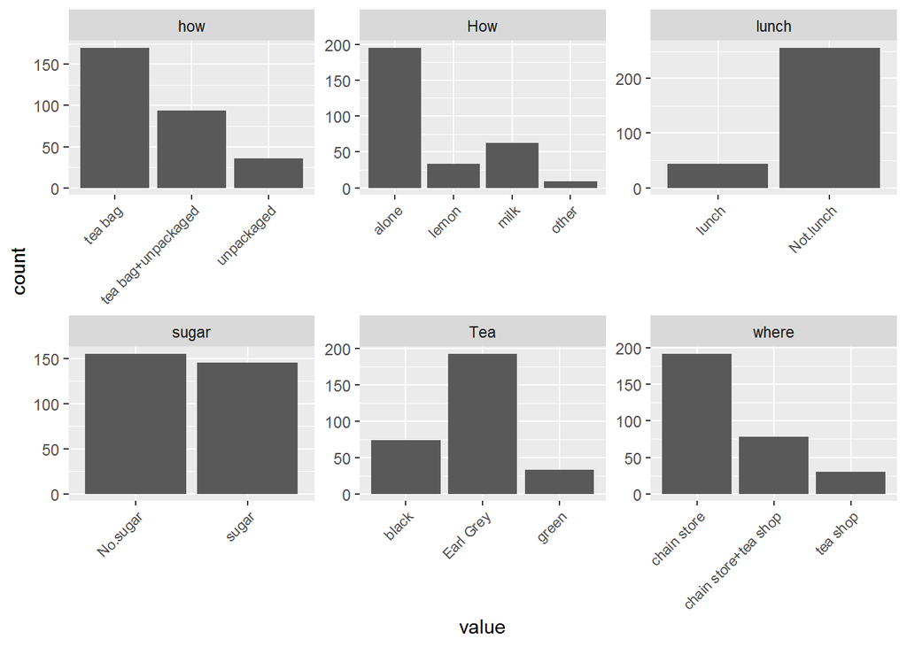

```r
gather(tea_time) %>% ggplot(aes(value)) + facet_wrap("key", scales = "free") + geom_bar() + theme(axis.text.x = element_text(angle = 45, hjust = 1, size = 8))
```

#### Multiple Correspondence Analysis.

A MCA Biplot shows the possible variable pattern, the distance between them, gives a measure of their similarity. To run a MCA we use the following code:

```r
library(MASS)
mca <- MCA(tea_time, graph = FALSE)
```

Here we can see the Scree plot:

[output not shown]

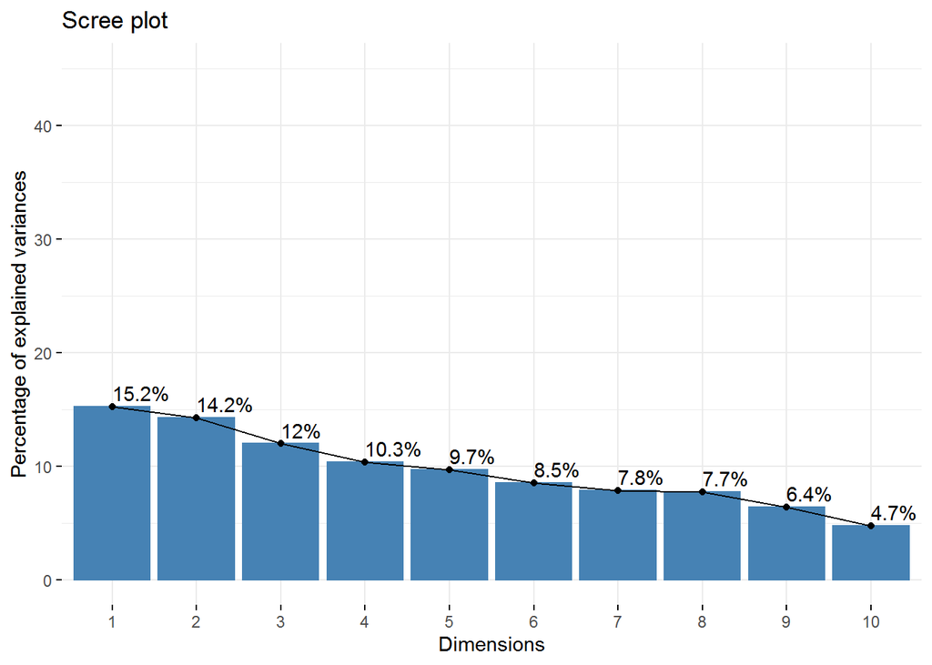

To visualize the MCA variable togheter with the individuals I will use a different procedure, because sometimes the biplot is a bit chaotic due to high concentrations. First I find the number of categories per variables:

```r
cats = apply(tea_time, 2, function(x) nlevels(as.factor(x)))
cats
```

```
##   Tea   How   how sugar where lunch
##     3     4     3     2     3     2
```

Then I obtain the table of eigenvalues, the column and heads coordinates which will form the data frames:

```r
mca$eig
```

```
##        eigenvalue percentage of variance cumulative percentage of variance
## dim 1  0.27937118              15.238428                          15.23843
## dim 2  0.26092645              14.232352                          29.47078
## dim 3  0.21933575              11.963768                          41.43455
## dim 4  0.18943794              10.332978                          51.76753
## dim 5  0.17722310               9.666715                          61.43424
## dim 6  0.15617745               8.518770                          69.95301
## dim 7  0.14375727               7.841306                          77.79432
## dim 8  0.14126310               7.705260                          85.49958
## dim 9  0.11717818               6.391537                          91.89111
## dim 10 0.08660997               4.724180                          96.61529
## dim 11 0.06205294               3.384706                         100.00000
```

```r
head(mca$var$coord)
```

```
##                 Dim 1       Dim 2       Dim 3       Dim 4       Dim 5
## black      0.47266156  0.09385258 -1.08063006  0.56186080  0.55465156
## Earl Grey -0.26425693  0.12347079  0.43288074  0.01902771 -0.21547686
## green      0.48559492 -0.93257436 -0.10846539 -1.37121354  0.01644904
## alone     -0.01774999 -0.26156928 -0.11267800 -0.36538842 -0.39693332
## lemon      0.66914791  0.53068346  1.32935122  1.00939803 -0.37701185
## milk      -0.33671028  0.27164647  0.01305056  0.25378949  1.57343677
```

```r
head(mca$ind$coord)
```

```
##        Dim 1      Dim 2      Dim 3      Dim 4        Dim 5
## 1 -0.2975376 -0.3278777 -0.3272610  0.3649751 -0.001711145
## 2 -0.2371102 -0.1360322 -0.6954324  0.2938098  0.818716502
## 3 -0.3689027 -0.3003457 -0.2015593 -0.1511548 -0.266254544
## 4 -0.5299062 -0.3182139  0.2113554  0.1571100 -0.306607147
## 5 -0.3689027 -0.3003457 -0.2015593 -0.1511548 -0.266254544
## 6 -0.3689027 -0.3003457 -0.2015593 -0.1511548 -0.266254544
```

```r
mca_vars_df = data.frame(mca$var$coord, Variable = rep(names(cats),
                                                       cats))
mca_obs_df = data.frame(mca$ind$coord)
```

With these values I produced the following plot:

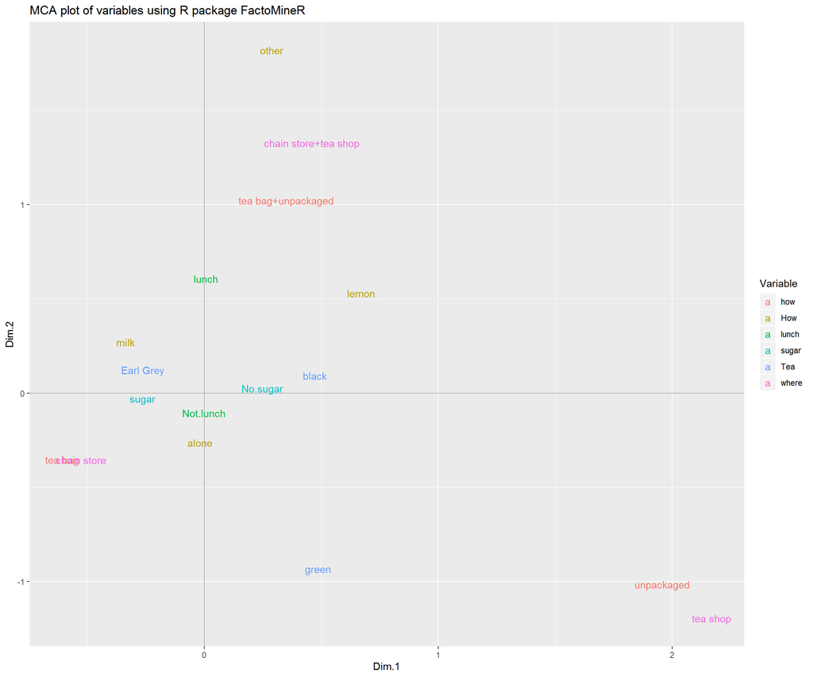

```r
ggplot(data = mca_vars_df, aes(x = Dim.1, y = Dim.2, label = rownames(mca_vars_df))) +    geom_hline(yintercept = 0, colour = "gray70") + geom_vline(xintercept = 0,                        colour = "gray70") + geom_text(aes(colour = Variable)) + ggtitle("MCA plot of variables using R package FactoMineR")
```

We can develop the plot to include observations and categories as in a MCA biplot. Because of the overlapping of the individuals, there will be instead the use of density curves to see the zones of high concentration:

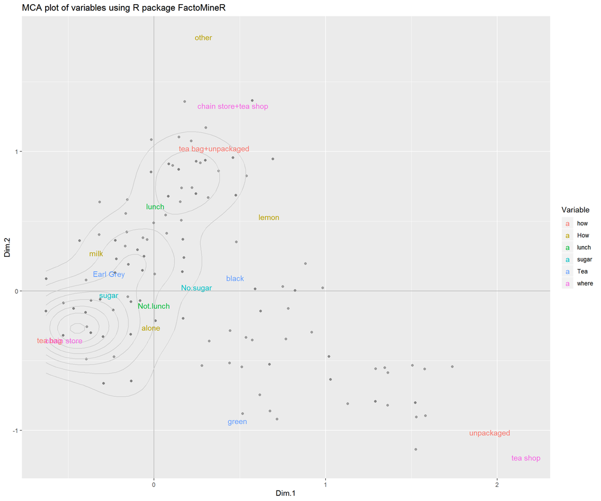

```r
ggplot(data = mca_obs_df, aes(x = Dim.1, y = Dim.2)) + geom_hline(yintercept = 0, colour = "gray70") + geom_vline(xintercept = 0, colour = "gray70") + geom_point(colour = "gray50",
alpha = 0.7) + geom_density2d(colour = "gray80") + geom_text(data = mca_vars_df,
aes(x = Dim.1, y = Dim.2, label = rownames(mca_vars_df), colour = Variable)) + ggtitle("MCA plot of variables using R package FactoMineR") + scale_colour_discrete(name = "Variable")
```

Here we see the `summary()` of the mca, which will be commmented on, in the next section:

```
##
## Call:
## MCA(X = tea_time, graph = FALSE)
##
##
## Eigenvalues
##                        Dim.1   Dim.2   Dim.3   Dim.4   Dim.5   Dim.6
## Variance               0.279   0.261   0.219   0.189   0.177   0.156
## % of var.             15.238  14.232  11.964  10.333   9.667   8.519
## Cumulative % of var.  15.238  29.471  41.435  51.768  61.434  69.953
##                        Dim.7   Dim.8   Dim.9  Dim.10  Dim.11
## Variance               0.144   0.141   0.117   0.087   0.062
## % of var.              7.841   7.705   6.392   4.724   3.385
## Cumulative % of var.  77.794  85.500  91.891  96.615 100.000
##
## Individuals (the 10 first)
##                       Dim.1    ctr   cos2    Dim.2    ctr   cos2    Dim.3
## 1                  | -0.298  0.106  0.086 | -0.328  0.137  0.105 | -0.327
## 2                  | -0.237  0.067  0.036 | -0.136  0.024  0.012 | -0.695
## 3                  | -0.369  0.162  0.231 | -0.300  0.115  0.153 | -0.202
## 4                  | -0.530  0.335  0.460 | -0.318  0.129  0.166 |  0.211
## 5                  | -0.369  0.162  0.231 | -0.300  0.115  0.153 | -0.202
## 6                  | -0.369  0.162  0.231 | -0.300  0.115  0.153 | -0.202
## 7                  | -0.369  0.162  0.231 | -0.300  0.115  0.153 | -0.202
## 8                  | -0.237  0.067  0.036 | -0.136  0.024  0.012 | -0.695
## 9                  |  0.143  0.024  0.012 |  0.871  0.969  0.435 | -0.067
## 10                 |  0.476  0.271  0.140 |  0.687  0.604  0.291 | -0.650
##                       ctr   cos2
## 1                   0.163  0.104 |
## 2                   0.735  0.314 |
## 3                   0.062  0.069 |
## 4                   0.068  0.073 |
## 5                   0.062  0.069 |
## 6                   0.062  0.069 |
## 7                   0.062  0.069 |
## 8                   0.735  0.314 |
## 9                   0.007  0.003 |
## 10                  0.643  0.261 |
##
## Categories (the 10 first)
```

[output cut: 16 more lines]

```
## lemon                0.035   3.226 |   1.329  14.771   0.218   8.081 |
## milk                 0.020   2.422 |   0.013   0.003   0.000   0.116 |
## other                0.102   5.534 |  -2.524  14.526   0.197  -7.676 |
## tea bag              0.161  -6.941 |  -0.065   0.183   0.006  -1.287 |
## tea bag+unpackaged   0.478  11.956 |   0.019   0.009   0.000   0.226 |
## unpackaged           0.141  -6.482 |   0.257   0.602   0.009   1.640 |
##
## Categorical variables (eta2)
##                      Dim.1 Dim.2 Dim.3
## Tea                | 0.126 0.108 0.410 |
## How                | 0.076 0.190 0.394 |
## how                | 0.708 0.522 0.010 |
## sugar              | 0.065 0.001 0.336 |
## where              | 0.702 0.681 0.055 |
## lunch              | 0.000 0.064 0.111 |
```

#### Comments.

In this output we can see the *Eigenvalues*, in other words the variances and the percentage of variances retained by each dimensions.

There are also *individuals* coordinates, and contribution to the dimension expressed in percentage, and the *cos<sup>2</sup>*, the squared correlations on the dimensions.

In the *categories* section, we see the coordinates of the varibale categories, the contribution in percentage, the *cos<sup>2</sup>* and *v.test* value that follows the normale distribution. If it is below/above 1.96 + o - it is significantly different from zero. The *categorical variables* shows the squared correlation between each variable and dimensions. If the value is close to one it suggests a strong link with the variable and dimension.